# IODS course project

Let’s draw a plot of it:

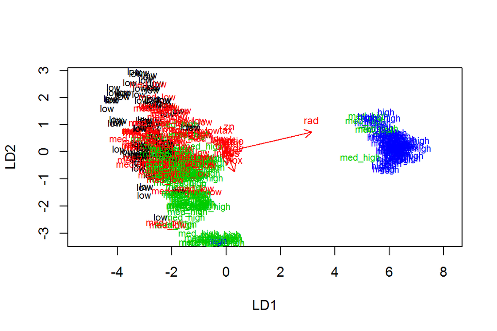

Let’s save the crimecategories from the testset and then remove crime from the test dataset. Then let’s predict the classes with the test data and produce crosstabulation of the results:

```
##           predicted
## correct    low med_low med_high high
##   low       15       8        1    0
##   med_low    5      14       12    0
##   med_high   0       2       18    1
##   high       0       0        0   26
```

Reloading the Boston-dataset and scaling it. Let’s then use eucledian distance to calculate the distances.

```
##    Min. 1st Qu.  Median    Mean 3rd Qu.    Max.
##  0.1343  3.4625  4.8241  4.9111  6.1863 14.3970
```

Let’s perform kmeans clustering with 4 centers and draw a plot of the clusters we obtain:

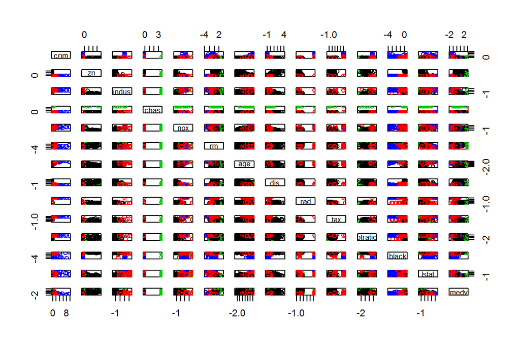

There seems to be quite a lot of overlapping between the clusters. The problem here is that we don’t yet know what is the optimal number of clusters. We should find the solution were the variation within the clusters is as small as possible. So let’s calculate the total within cluster sum of squares for different number of clusters and visualize the results:

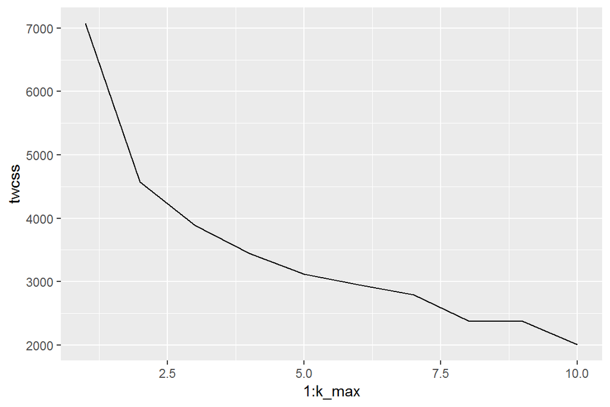

Here we can see a clear change of direction in the graph around 2. We can see that the total within cluster sum of squares decreases somewhat radically till 2 clusters, but after that, changes in variation are less clear. Let’s choose 2 as the number of centers.

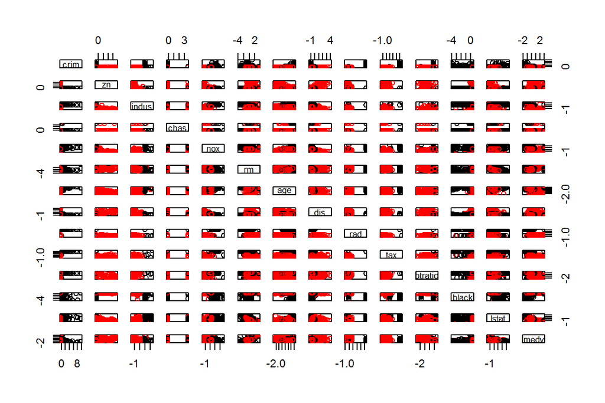

Okay, that is probably a slight improvement to the previous, but I still wouldn’t call it perfect.

## Dimensionality reduction techniques

Let’s start by taking a graphical overview of the human data and look at the summeries of the variables

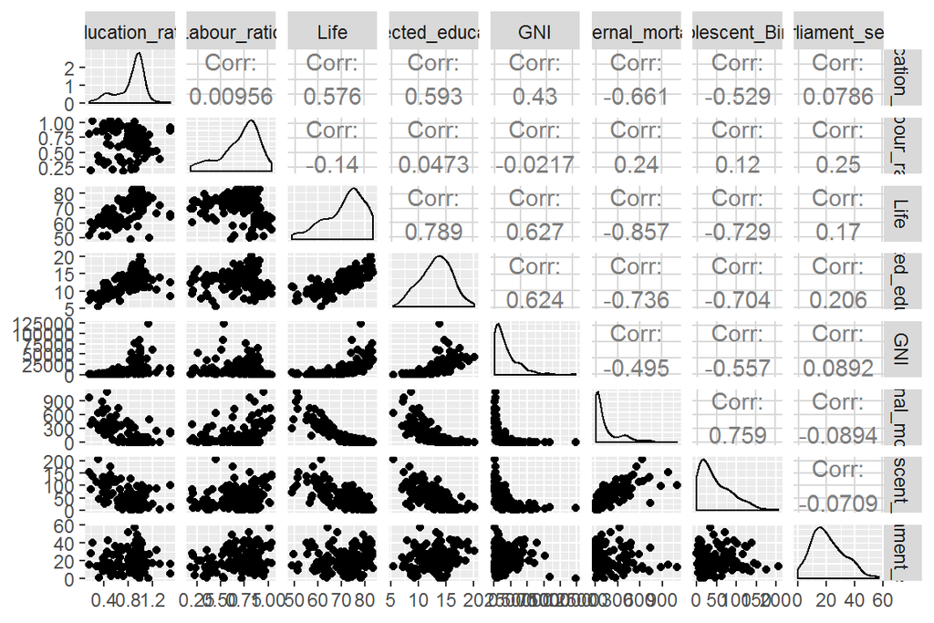

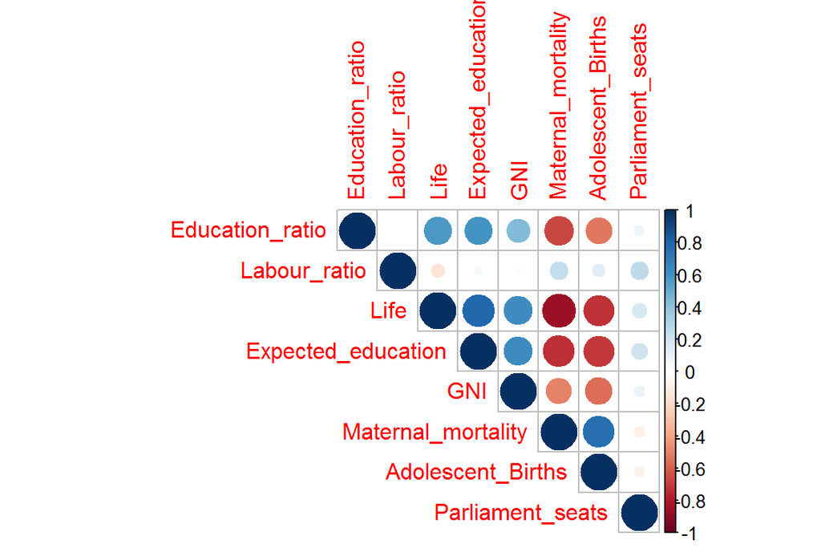

```
##  Education_ratio   Labour_ratio         Life       Expected_education
##  Min.   :0.1717   Min.   :0.1857   Min.   :49.00   Min.   : 5.40
##  1st Qu.:0.7264   1st Qu.:0.5984   1st Qu.:66.30   1st Qu.:11.25
##  Median :0.9375   Median :0.7535   Median :74.20   Median :13.50
##  Mean   :0.8529   Mean   :0.7074   Mean   :71.65   Mean   :13.18
##  3rd Qu.:0.9968   3rd Qu.:0.8535   3rd Qu.:77.25   3rd Qu.:15.20
##  Max.   :1.4967   Max.   :1.0380   Max.   :83.50   Max.   :20.20
##       GNI         Maternal_mortality Adolescent_Births Parliament_seats
##  Min.   :   581   Min.   :   1.0     Min.   :  0.60    Min.   : 0.00
##  1st Qu.:  4198   1st Qu.:  11.5     1st Qu.: 12.65    1st Qu.:12.40
##  Median : 12040   Median :  49.0     Median : 33.60    Median :19.30
##  Mean   : 17628   Mean   : 149.1     Mean   : 47.16    Mean   :20.91
##  3rd Qu.: 24512   3rd Qu.: 190.0     3rd Qu.: 71.95    3rd Qu.:27.95
##  Max.   :123124   Max.   :1100.0     Max.   :204.80    Max.   :57.50
```

Many of the variables correlate highly with each other. We can see, for example, that education ratio correlates positively with life expectancy, expected education and GNI, and negatively with maternal mortality and adolescent birth rate. Life expectancy correlates negatively with maternal mortality and adolescent birth rate (not exactly surprising), and has strong postitive correlation with GNI and expected education.

Then it’s time to perform some principal component analysis and draw a biplot of it.

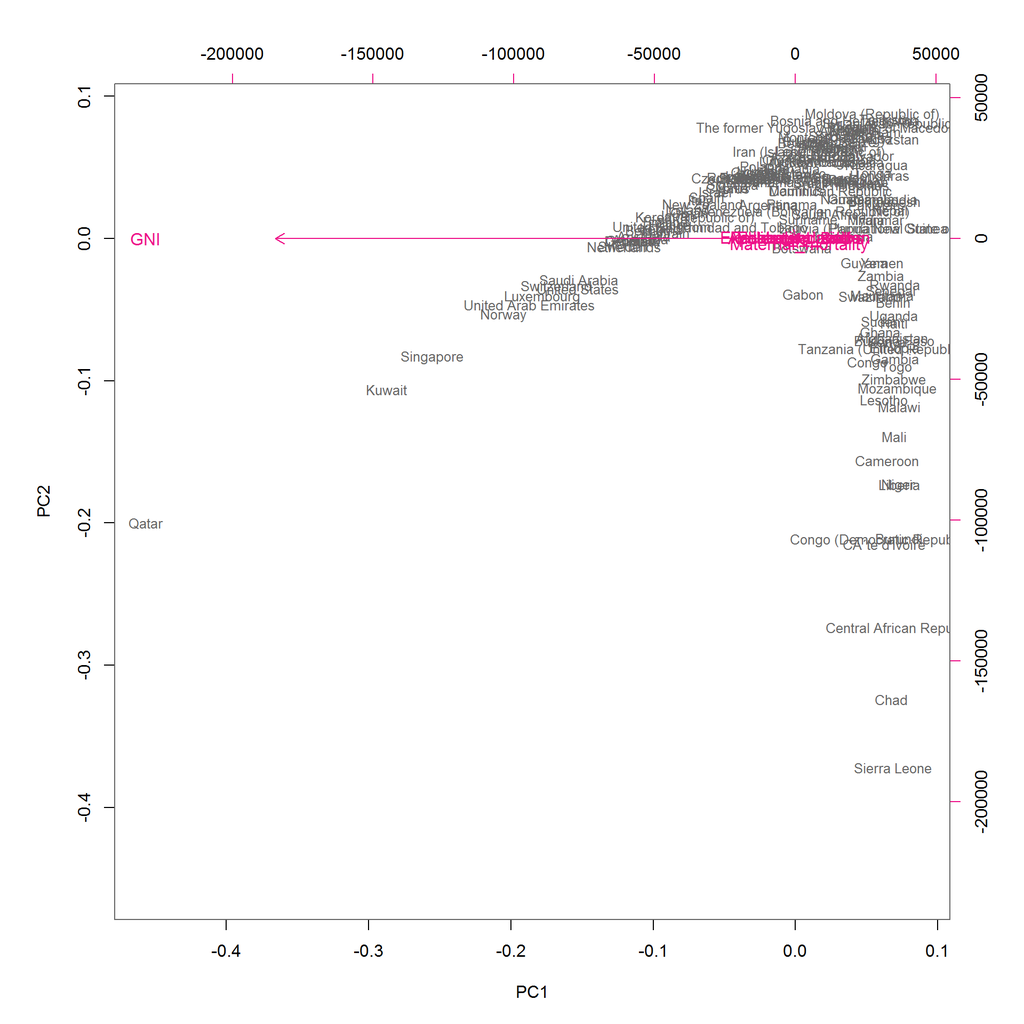

This doesn’t look super nice. The problem here is that PCA tries to explain the variance in the data the best it can. Since the range for GNI is far larger than for the other variables, PCA will select to project almost entirely in the direction of GNI.

Let’s see then what happens when we standardize the dataset and run the analysis again.

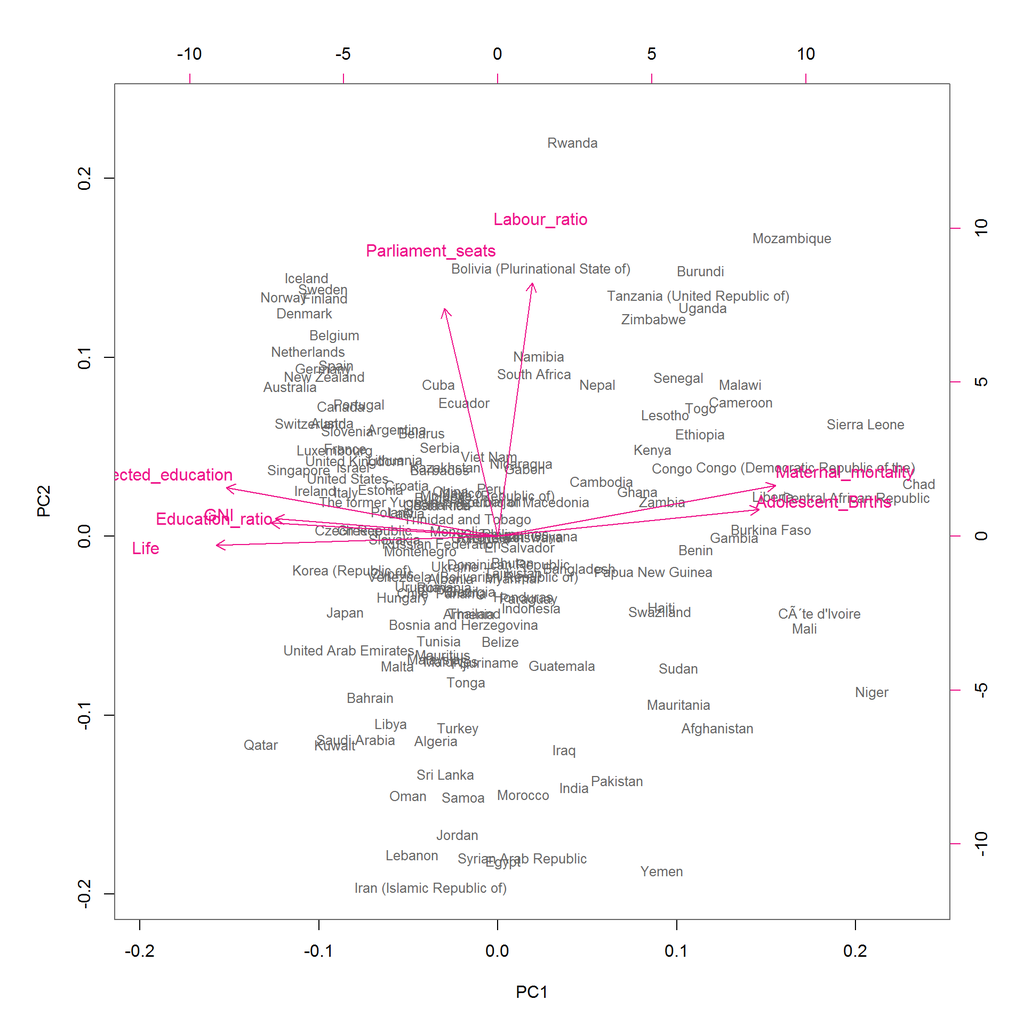

All of these variable arrows are in line with the x-axis, indicating that these are the variables which by the first principal component separates countries. This makes sense: it does seem like charasteristics related to well-being and not-that-well-being separate between countries well.

The second principal component correlates strongly with gender equality related variabales. Countries which locate up in the figure gain high values on equality measures, and countries which locate down in the figure have lower values on the equality measures. We can see up in the figure Rwanda Iceland, Norway and Finland. Down in the figure we can see countries like Iran and Yemen.

Let’s move on to the tea data then. Let’s look at it sructure, choose a few columns to keep an visualize it.

```
## 'data.frame':    300 obs. of  36 variables:
##  $ breakfast       : Factor w/ 2 levels "breakfast","Not.breakfast": 1 1 2 2 1 2 1 2 1 1 ...
##  $ tea.time        : Factor w/ 2 levels "Not.tea time",..: 1 1 2 1 1 1 2 2 2 1 ...
##  $ evening         : Factor w/ 2 levels "evening","Not.evening": 2 2 1 2 1 2 2 1 2 1 ...
##  $ lunch           : Factor w/ 2 levels "lunch","Not.lunch": 2 2 2 2 2 2 2 2 2 2 ...
##  $ dinner          : Factor w/ 2 levels "dinner","Not.dinner": 2 2 1 1 2 1 2 2 2 2 ...
##  $ always          : Factor w/ 2 levels "always","Not.always": 2 2 2 2 1 2 2 2 2 2 ...
##  $ home            : Factor w/ 2 levels "home","Not.home": 1 1 1 1 1 1 1 1 1 1 ...
##  $ work            : Factor w/ 2 levels "Not.work","work": 1 1 2 1 1 1 1 1 1 1 ...
##  $ tearoom         : Factor w/ 2 levels "Not.tearoom",..: 1 1 1 1 1 1 1 1 1 2 ...
##  $ friends         : Factor w/ 2 levels "friends","Not.friends": 2 2 1 2 2 2 1 2 2 2 ...
##  $ resto           : Factor w/ 2 levels "Not.resto","resto": 1 1 2 1 1 1 1 1 1 1 ...
##  $ pub             : Factor w/ 2 levels "Not.pub","pub": 1 1 1 1 1 1 1 1 1 1 ...
##  $ Tea             : Factor w/ 3 levels "black","Earl Grey",..: 1 1 2 2 2 2 2 1 2 1 ...
##  $ How             : Factor w/ 4 levels "alone","lemon",..: 1 3 1 1 1 1 1 3 3 1 ...
```

[output cut: 22 more lines]

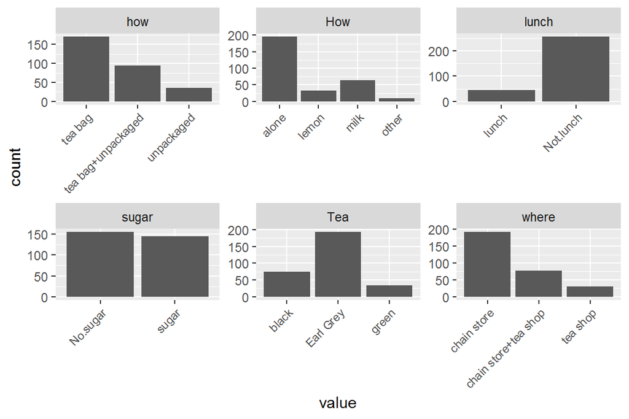

Then some multiple correspondence analysis:

```
##
## Call:
## MCA(X = tea_time, graph = FALSE)
##
##
## Eigenvalues
##                        Dim.1   Dim.2   Dim.3   Dim.4   Dim.5   Dim.6
## Variance               0.279   0.261   0.219   0.189   0.177   0.156
## % of var.             15.238  14.232  11.964  10.333   9.667   8.519
## Cumulative % of var.  15.238  29.471  41.435  51.768  61.434  69.953
##                        Dim.7   Dim.8   Dim.9  Dim.10  Dim.11
## Variance               0.144   0.141   0.117   0.087   0.062
## % of var.              7.841   7.705   6.392   4.724   3.385
## Cumulative % of var.  77.794  85.500  91.891  96.615 100.000
##
## Individuals (the 10 first)
##                       Dim.1    ctr   cos2    Dim.2    ctr   cos2    Dim.3
## 1                  | -0.298  0.106  0.086 | -0.328  0.137  0.105 | -0.327
## 2                  | -0.237  0.067  0.036 | -0.136  0.024  0.012 | -0.695
## 3                  | -0.369  0.162  0.231 | -0.300  0.115  0.153 | -0.202
## 4                  | -0.530  0.335  0.460 | -0.318  0.129  0.166 |  0.211
## 5                  | -0.369  0.162  0.231 | -0.300  0.115  0.153 | -0.202
## 6                  | -0.369  0.162  0.231 | -0.300  0.115  0.153 | -0.202
## 7                  | -0.369  0.162  0.231 | -0.300  0.115  0.153 | -0.202
## 8                  | -0.237  0.067  0.036 | -0.136  0.024  0.012 | -0.695
## 9                  |  0.143  0.024  0.012 |  0.871  0.969  0.435 | -0.067
## 10                 |  0.476  0.271  0.140 |  0.687  0.604  0.291 | -0.650
##                       ctr   cos2
## 1                   0.163  0.104 |
## 2                   0.735  0.314 |
## 3                   0.062  0.069 |
## 4                   0.068  0.073 |
## 5                   0.062  0.069 |
## 6                   0.062  0.069 |
## 7                   0.062  0.069 |
## 8                   0.735  0.314 |
## 9                   0.007  0.003 |
## 10                  0.643  0.261 |
##
## Categories (the 10 first)
```

[output cut: 16 more lines]

```
## lemon                0.035   3.226 |   1.329  14.771   0.218   8.081 |
## milk                 0.020   2.422 |   0.013   0.003   0.000   0.116 |
## other                0.102   5.534 |  -2.524  14.526   0.197  -7.676 |
## tea bag              0.161  -6.941 |  -0.065   0.183   0.006  -1.287 |
## tea bag+unpackaged   0.478  11.956 |   0.019   0.009   0.000   0.226 |
## unpackaged           0.141  -6.482 |   0.257   0.602   0.009   1.640 |
##
## Categorical variables (eta2)
##                      Dim.1 Dim.2 Dim.3
## Tea                | 0.126 0.108 0.410 |
## How                | 0.076 0.190 0.394 |
## how                | 0.708 0.522 0.010 |
## sugar              | 0.065 0.001 0.336 |
## where              | 0.702 0.681 0.055 |
## lunch              | 0.000 0.064 0.111 |
```

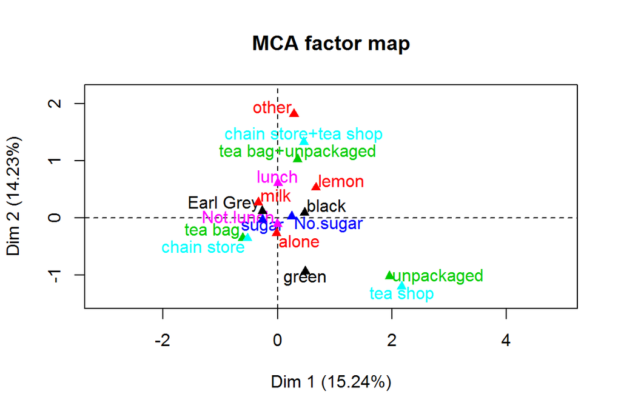

From the plot here we can see that the first dimension explains about 15% of the variance and the second dimension explains about 14% of the variance. Looks like first dimension seperates between those who shop their tea from the tea shop and drink it unpacked, and those who by it from chain store and drink it from a bag. The second dimension isn’t as clear. Up in the figure we can see categories like other, chain store + tea shop and tea bag + unpackaged and down in the figure we can see green, unpackaged and tea shop. Let’s take a closer look.

```
## Multiple Correspondence Analysis Results for individuals
##  ===================================================
##   Name       Description
## 1 "$coord"   "Coordinates for the individuals"
## 2 "$cos2"    "Cos2 for the individuals"
## 3 "$contrib" "contributions of the individuals"
```

```
## Multiple Correspondence Analysis Results for variables
##  ===================================================
##   Name       Description
## 1 "$coord"   "Coordinates for categories"
## 2 "$cos2"    "Cos2 for categories"
## 3 "$contrib" "contributions of categories"
```

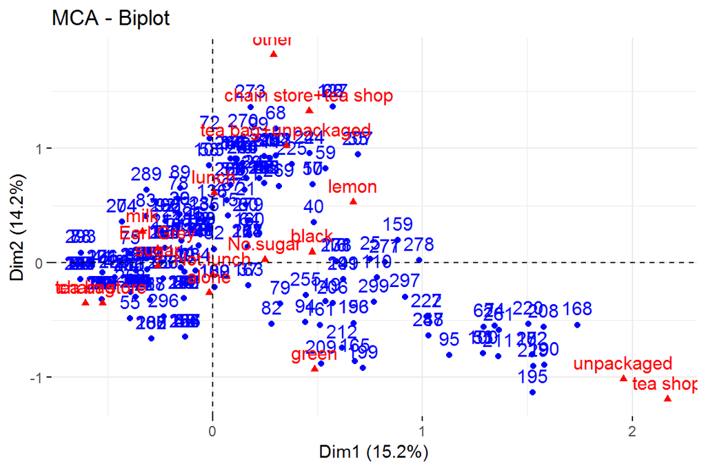

Here we have a biplot of individuals and categories.

Let’s then explore the correlation of the individual variable categories with the first two dimensions

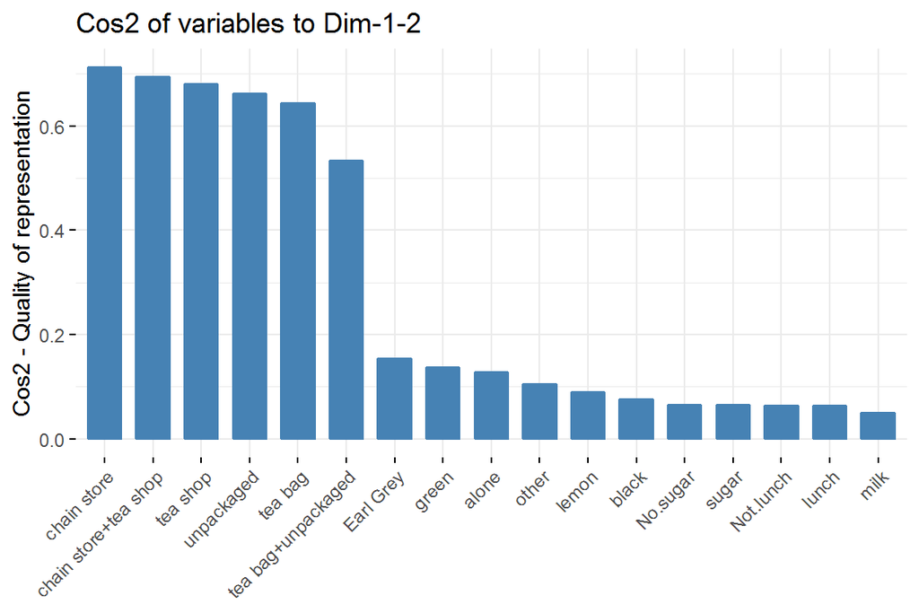

Looking at this plot it is pretty easy to conlcude that only few of the variable categories are actually correlating with these dimensions, and a position of the rest of the variables in the map should be interpreted cautiously.

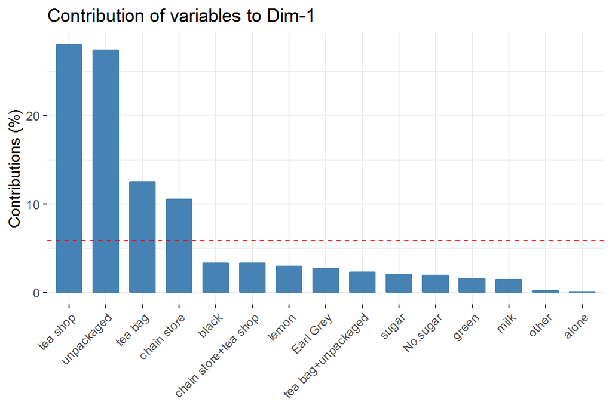

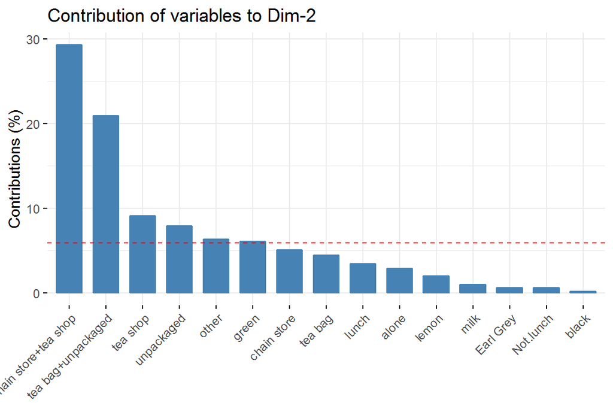

Here we can see how which variable categories contribute seperately to dimensions 1 and 2. The results aren’t very impressive and the original plot should be interpreted cautiosly.

# Analysis of longitudinal data

## Part 1

Loading the RATS data and taking a look at it

```
## 'data.frame':    176 obs. of  5 variables:
##  $ ID    : int  1 2 3 4 5 6 7 8 9 10 ...
##  $ Group : int  1 1 1 1 1 1 1 1 2 2 ...
##  $ WD    : Factor w/ 11 levels "WD1","WD15","WD22",..: 1 1 1 1 1 1 1 1 1 1 ...
##  $ Weight: int  240 225 245 260 255 260 275 245 410 405 ...
##  $ Time  : int  1 1 1 1 1 1 1 1 1 1 ...
```

```
##        ID            Group            WD         Weight
##  Min.   : 1.00   Min.   :1.00   WD1    :16   Min.   :225.0
##  1st Qu.: 4.75   1st Qu.:1.00   WD15   :16   1st Qu.:267.0
##  Median : 8.50   Median :1.50   WD22   :16   Median :344.5
##  Mean   : 8.50   Mean   :1.75   WD29   :16   Mean   :384.5
##  3rd Qu.:12.25   3rd Qu.:2.25   WD36   :16   3rd Qu.:511.2
##  Max.   :16.00   Max.   :3.00   WD43   :16   Max.   :628.0
##                                 (Other):80
##       Time
##  Min.   : 1.00
##  1st Qu.:15.00
##  Median :36.00
##  Mean   :33.55
##  3rd Qu.:50.00
##  Max.   :64.00
##
```

Okay, for some reason factorizing has failed. Let’s do it quickly again.

```
## 'data.frame':    176 obs. of  5 variables:
##  $ ID    : Factor w/ 16 levels "1","2","3","4",..: 1 2 3 4 5 6 7 8 9 10 ...
##  $ Group : Factor w/ 3 levels "1","2","3": 1 1 1 1 1 1 1 1 2 2 ...
##  $ WD    : Factor w/ 11 levels "WD1","WD15","WD22",..: 1 1 1 1 1 1 1 1 1 1 ...
##  $ Weight: int  240 225 245 260 255 260 275 245 410 405 ...
##  $ Time  : int  1 1 1 1 1 1 1 1 1 1 ...
```

Looks better! Lets start by a little graphical display. Let’s try and plot the weights for all the rats, differentiating between the three groups.

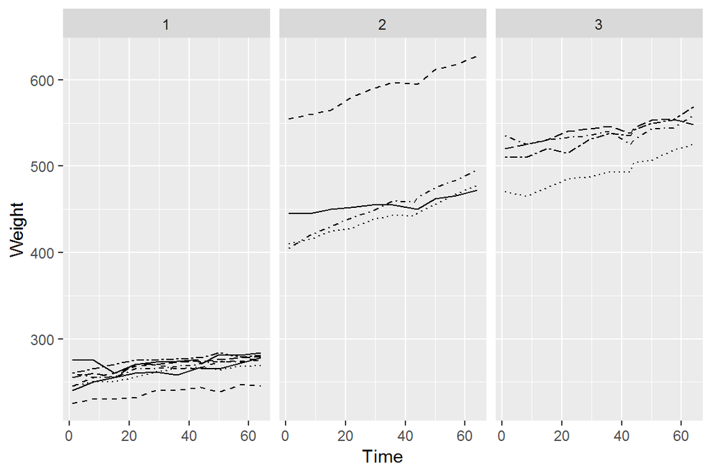

First of all, we can see that almost all the rats gain weight during the study. We can also see that those rats with a higher baseline weight will weight more throughout the study. And third, we can see there are clear differences between the three groups. Those in the group 1 have significantly lower weights throughout the study than those in groups 2 and 3.

Let’s continue our investigations by standardizing the variable Weight and drawing the plot again with the standardized values.

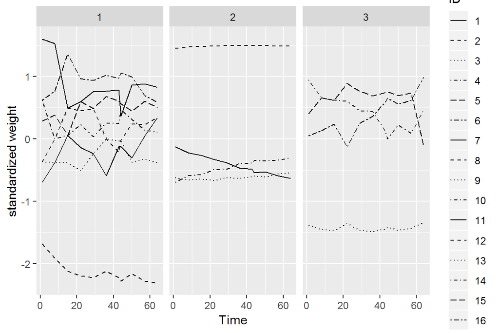

From the standardized plot we can see even more clearly, that those who start off with higher values will attain higher values in all phases of the study. The phenomena is called tracking.

Wouldn’t it be more interesting to observe summary measures of the observations rather than indivdually each of them? Let’s produce a plot of the group means and look at them.

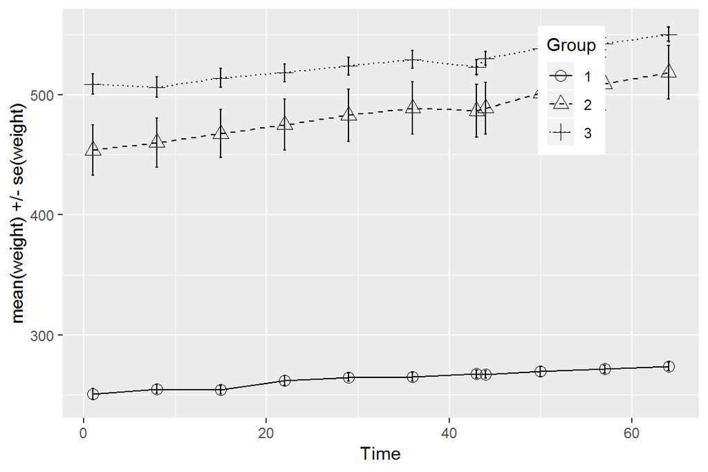

Now it’s time to check out wheter we have some outliers messing our game.

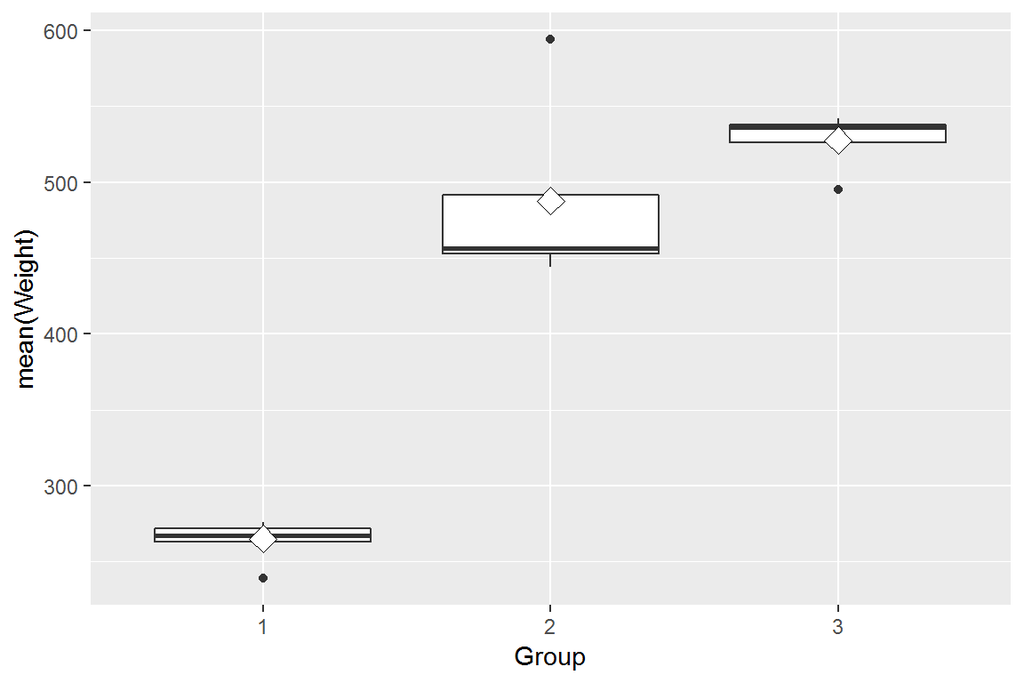

Okay, here we have a boxplot displaying mean values for the three groups. We have a few observations that could be considered as outliers. In group two, there seems to be a variable that gains a mean of almost 600mg. Maybe we should filter that one out?

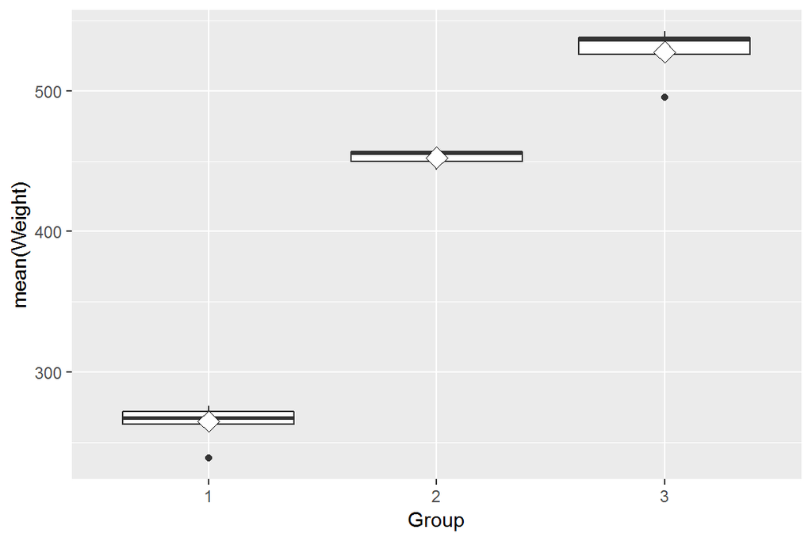

Okay, looks like the removing of the outlier was indeed succesfull!

Let’s then perform some analysis of variance to make sure to look at the differences between the groups.

```
##             Df Sum Sq Mean Sq F value   Pr(>F)
## Group        2 207659  103830   501.8 2.72e-12 ***
## Residuals   12   2483     207
## ---
## Signif. codes:  0 '***' 0.001 '**' 0.01 '*' 0.05 '.' 0.1 ' ' 1
```

Alright, there definetely is some significant difference between these groups! Let’s now include the baseline weight into the analysis as a covariate and check out the results again. This is done because the baseline measure is often correlated with the summary measure.

```
## Analysis of Variance Table
##
## Response: mean
##           Df Sum Sq Mean Sq   F value   Pr(>F)
## baseline   1 253625  253625 1859.8201 1.57e-14 ***
## Group      2    879     439    3.2219  0.07586 .
## Residuals 12   1636     136
## ---
## Signif. codes:  0 '***' 0.001 '**' 0.01 '*' 0.05 '.' 0.1 ' ' 1
```

While the baseline weight is strongly related to the mean weight, there is no evidence of a group diffence. We can conclude that differences in the baseline weights explain all the differences in variance between the three groups.

That’s it for that, let’s move onto the BPRS-data.

## Part 2

Loading the data and correcting the failed attempts to factorizing

```
## 'data.frame':    360 obs. of  5 variables:
##  $ treatment: Factor w/ 2 levels "1","2": 1 1 1 1 1 1 1 1 1 1 ...
##  $ subject  : Factor w/ 40 levels "1","2","3","4",..: 1 2 3 4 5 6 7 8 9 10 ...
##  $ weeks    : Factor w/ 9 levels "week0","week1",..: 1 1 1 1 1 1 1 1 1 1 ...
##  $ bprs     : int  42 58 54 55 72 48 71 30 41 57 ...
##  $ week     : int  0 0 0 0 0 0 0 0 0 0 ...
```

Let’s start by plotting the data and checking it out

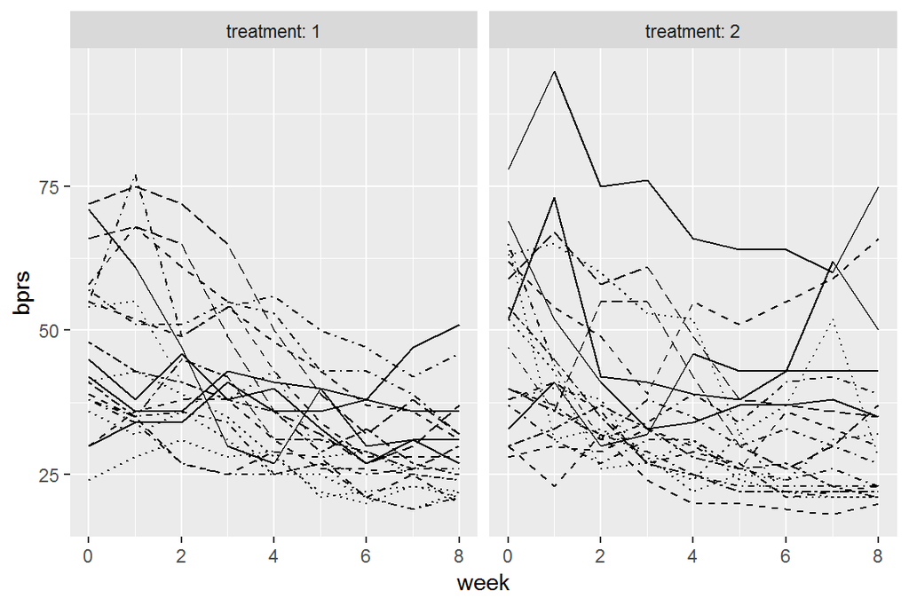

Okay, from this plot we can see that for almost all the subjects, bprs scores seem to lower during the study. Second of all we can see that those who start off with a high bprs score are more likely to have higher scores throughout the study. And third, there doesn’t seem to be a huge different among the treatments.

Let’s just ignore for a while the whole repeated measures design and just fit the data into a regression model.

```
##
## Call:
## lm(formula = bprs ~ week + treatment, data = BPRSL)
##
## Residuals:
##     Min      1Q  Median      3Q     Max
## -22.454  -8.965  -3.196   7.002  50.244
##
## Coefficients:
##             Estimate Std. Error t value Pr(>|t|)
## (Intercept)  46.4539     1.3670  33.982   <2e-16 ***
## week         -2.2704     0.2524  -8.995   <2e-16 ***
## treatment2    0.5722     1.3034   0.439    0.661
## ---
## Signif. codes:  0 '***' 0.001 '**' 0.01 '*' 0.05 '.' 0.1 ' ' 1
##
## Residual standard error: 12.37 on 357 degrees of freedom
## Multiple R-squared:  0.1851, Adjusted R-squared:  0.1806
## F-statistic: 40.55 on 2 and 357 DF,  p-value: < 2.2e-16
```

Changes in time seem to predict significantly scores in bprs, but treatment doesn’t. Since this model is inherently flawed, let’s not use too long it’s interpretation.

Let’s then fit one random intercept model! Random intercept model allows the linear regression to differ in intercept for each subject. That way we can take into account the fact that different subjects start off with different baseline scores.

```
## Linear mixed model fit by maximum likelihood  ['lmerMod']
## Formula: bprs ~ week + treatment + (1 | subject)
##    Data: BPRSL
##
##      AIC      BIC   logLik deviance df.resid
##   2582.9   2602.3  -1286.5   2572.9      355
##
## Scaled residuals:
##      Min       1Q   Median       3Q      Max
## -2.27506 -0.59909 -0.06104  0.44226  3.15835
##
## Random effects:
##  Groups   Name        Variance Std.Dev.
##  subject  (Intercept) 97.39    9.869
##  Residual             54.23    7.364
## Number of obs: 360, groups:  subject, 40
##
## Fixed effects:
##             Estimate Std. Error t value
## (Intercept)  46.4539     2.3521  19.750
## week         -2.2704     0.1503 -15.104
## treatment2    0.5722     3.2159   0.178
##
## Correlation of Fixed Effects:
##            (Intr) week
## week       -0.256
## treatment2 -0.684  0.000
```

Next we have the random intercept and random slope model! The random intercept and random slope model allows the linear regression to differ not only in intercept, but also in slope for different individuals.

```
## Linear mixed model fit by maximum likelihood  ['lmerMod']
## Formula: bprs ~ week + treatment + (week | subject)
##    Data: BPRSL
##
##      AIC      BIC   logLik deviance df.resid
##   2523.2   2550.4  -1254.6   2509.2      353
##
## Scaled residuals:
##     Min      1Q  Median      3Q     Max
## -2.4655 -0.5150 -0.0920  0.4347  3.7353
##
## Random effects:
##  Groups   Name        Variance Std.Dev. Corr
##  subject  (Intercept) 167.827  12.955
##           week          2.331   1.527   -0.67
##  Residual              36.747   6.062
## Number of obs: 360, groups:  subject, 40
##
## Fixed effects:
##             Estimate Std. Error t value
## (Intercept)  45.9830     2.6470  17.372
## week         -2.2704     0.2713  -8.370
## treatment2    1.5139     3.1392   0.482
##
## Correlation of Fixed Effects:
##            (Intr) week
## week       -0.545
## treatment2 -0.593  0.000
```

```
## Data: BPRSL
## Models:
## BPRS_ref: bprs ~ week + treatment + (1 | subject)
## BPRS_ref1: bprs ~ week + treatment + (week | subject)
##           Df    AIC    BIC  logLik deviance  Chisq Chi Df Pr(>Chisq)
## BPRS_ref   5 2582.9 2602.3 -1286.5   2572.9
## BPRS_ref1  7 2523.2 2550.4 -1254.6   2509.2 63.663      2  1.499e-14 ***
## ---
## Signif. codes:  0 '***' 0.001 '**' 0.01 '*' 0.05 '.' 0.1 ' ' 1
```

Let’s fit a model with the week*treatment interaction, and perfom the likelihood ratio test for this and the previous model.

```
## Linear mixed model fit by maximum likelihood  ['lmerMod']
## Formula: bprs ~ week * treatment + (week | subject)
##    Data: BPRSL
##
##      AIC      BIC   logLik deviance df.resid
##   2523.5   2554.5  -1253.7   2507.5      352
##
## Scaled residuals:
##     Min      1Q  Median      3Q     Max
## -2.4747 -0.5256 -0.0866  0.4435  3.7884
##
## Random effects:
##  Groups   Name        Variance Std.Dev. Corr
##  subject  (Intercept) 164.207  12.814
##           week          2.203   1.484   -0.66
##  Residual              36.747   6.062
## Number of obs: 360, groups:  subject, 40
##
## Fixed effects:
##                 Estimate Std. Error t value
## (Intercept)      47.8856     2.9840  16.047
## week             -2.6283     0.3752  -7.006
## treatment2       -2.2911     4.2201  -0.543
## week:treatment2   0.7158     0.5306   1.349
##
## Correlation of Fixed Effects:
##             (Intr) week   trtmn2
## week        -0.668
## treatment2  -0.707  0.473
## wek:trtmnt2  0.473 -0.707 -0.668
```

```
## Data: BPRSL
## Models:
## BPRS_ref1: bprs ~ week + treatment + (week | subject)
## BPRS_ref2: bprs ~ week * treatment + (week | subject)
##           Df    AIC    BIC  logLik deviance Chisq Chi Df Pr(>Chisq)
## BPRS_ref1  7 2523.2 2550.4 -1254.6   2509.2
## BPRS_ref2  8 2523.5 2554.6 -1253.7   2507.5  1.78      1     0.1821
```

Alright, it doesn’t look like the interaction term provided us a better model after all.

Let’s finish the assignement by plotting the fitted regression lines for each subject.

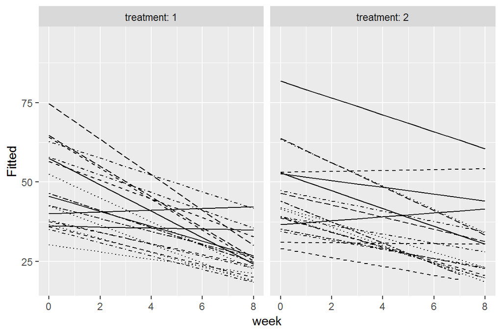